# SAP projekt - Analiza poadataka o igračima NHL lige

Pokušat ćemo preko histograma pokazati normalnosti

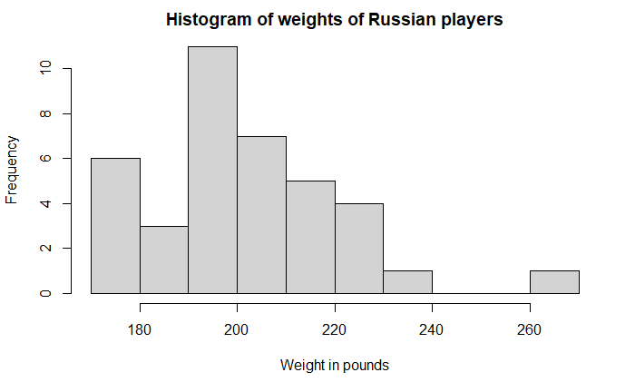

```r
hist(russian_players$Wt,
     breaks= 10,
     main='Histogram of weights of Russian players',
     xlab='Weight in pounds')
```

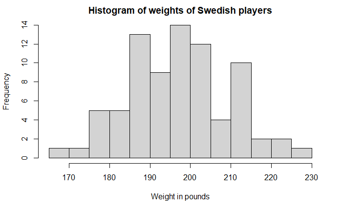

```r
hist(swedish_players$Wt ,
     breaks=10,
     main='Histogram of weights of Swedish players',
     xlab='Weight in pounds')
```

Iz histograma je možda teško vidljiva normalnost, pa ćemo probati s qqplot-ovima

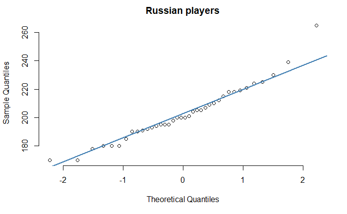

```r
qqnorm(russian_players$Wt, pch = 1, frame = FALSE,main='Russian players')
qqline(russian_players$Wt, col = "steelblue", lwd = 2)
```

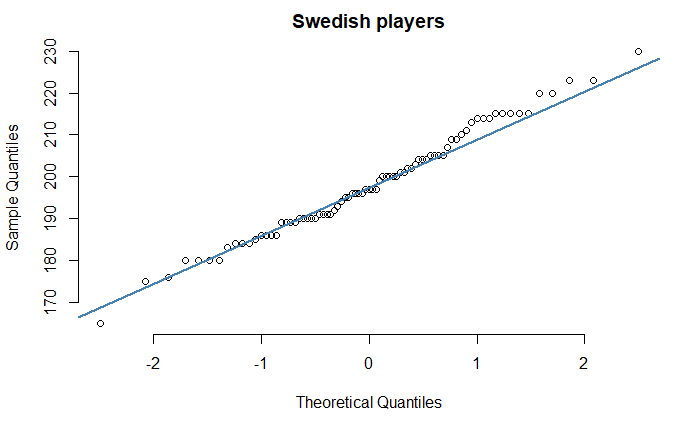

```r
qqnorm(swedish_players$Wt, pch = 1, frame = FALSE,main='Swedish players')
qqline(swedish_players$Wt, col = "steelblue", lwd = 2)
```

qqplotova daju bolju potvrdu da težine dolaze iz normalne distribucije stoga možemo pretpostavit normalnost te nastaviti sa t-testom.

Da bi smo proveli t-test trebamo još izračunati i varijance populacija.

```r
var(russian_players$Wt)
```

```
[1] 375.7248
```

```r
var(swedish_players$Wt)
```

```
[1] 161.8845
```

Razlika između varijanci je dosta velika,ali ipak ćemo provesti testiranje.Pretpostavit ćemo da su varijance jednake i to će biti H0,dok će alternativna hipoteza biti da nisu jednake.

Provest ćemo test nad varijancama kako bi provjerili naše pretpostavke.

```r
var.test(russian_players$Wt, swedish_players$Wt)
```

```
    F test to compare two variances

data:  russian_players$Wt and swedish_players$Wt
F = 2.3209, num df = 37, denom df = 78, p-value = 0.001846
alternative hypothesis: true ratio of variances is not equal to 1
95 percent confidence interval:
 1.363353 4.180389
sample estimates:
ratio of variances
          2.320944
```

p-vrijednost od 0.001846 nam govori da možemo odbaciti hipotezu $H_0$ te da su varijance naša dva uzorka nejednaka.

Provedimo sada t-test uz pretpostavku nejednakosti varijanci.

```r
t.test(russian_players$Wt, swedish_players$Wt, alt = "greater", var.equal = FALSE)
```

```
    Welch Two Sample t-test

data:  russian_players$Wt and swedish_players$Wt
t = 1.3598, df = 52.849, p-value = 0.08984
alternative hypothesis: true difference in means is greater than 0
95 percent confidence interval:
 -1.08641      Inf
sample estimates:
mean of x mean of y
 202.7105  198.0127
```

S obzirom da se naše društvo svakog dana sve više mijenja i napreduje u svim aspektima, ista je stvar i sa sportovim.Grane sporta poput nogometa,košarke,hokeja sve se više šire na globalnoj razini i postaju dostupnije mnogo većem broju ljudi nego prije.U domaćim ligama sve je više stranih igrača, a iznimka nije niti NHL.Tijekom godina sve više europskih igrača nastupa u NHL,stoga je naš sljedeći zadataka:Koliki udio NHL igrača čine igrači iz Europe,ako se pretpostavlja da oko 30 posto NHL igrača čine europski igrači?

###ZADATAK 5 ### UDIO EUROPSKIH IGRAČA U NHL Za analizu koristit ćemo test o jednoj proporciji H0 - p0 = 0.3 H1 - p0 < 0.3

```r
AllPlayers <- merge(AllSits,Goalies, all = TRUE)
```

```
tracemem[0x00000280ed243e00 -> 0x00000280efac3140]: merge.data.frame merge
tracemem[0x00000280efac3140 -> 0x00000280ed238b60]: .rowNamesDF<- row.names<-.data.frame row.names<- merge.data.frame merge
```

```r
nationality <- table(AllPlayers$Nat)
print(nationality)
```

```
AUT CAN CHE CZE DEU DNK FIN FRA GBR HRV LVA NOR RUS SVK SVN SWE USA
  3 450  14  38   7  10  39   4   1   1   2   2  42  13   1  89 267
```

Iz tablice vidimo da imamo 983 podataka, te da su svi igrači iz Europe ili Sjeverne Amerike

```r
n <- nrow(AllPlayers)
k <- nrow(AllPlayers[!AllPlayers$Nat %in% c("CAN", "USA"), ])

prop.test(x = k,n = n, p = 0.3 , alternative = "less")
```

```
    1-sample proportions test with continuity correction

data:  k out of n, null probability 0.3
X-squared = 3.9072, df = 1, p-value = 0.02404
alternative hypothesis: true p is less than 0.3
95 percent confidence interval:
 0.0000000 0.2950349
sample estimates:
        p
0.2706002
```

###ZAKLJUČAK

p-vrijednost iznosi 0.02404 možemo odbaciti $H_0$ hipotezu u korist $H_1$, odnosno možemo reći da manje od 30 posto svih NHL igrača čine igrači iz Europe.

###ZADATAK 6 ### POZICIJE I BODOVI

```r
require(dplyr)
PointsPoistion <- AllSits[,c("First.Name", "Last.Name","GP","Position","G","A","PTS")]

### UZIMAMO SAMO JEDNU POZICIJU U OBZIR
PointsPoistion$OnePosition <- word(PointsPoistion$Position, start = 1, sep = fixed("/"))

### PROVJERA VRIJEDNOSTI
unique(PointsPoistion$OnePosition)
```

```
[1] "LW" "C"  "RW" "D"
```

```r
### Tablice koje sadrže statistiku vezanu za poena,golove i asistencije
PointsStat <- PointsPoistion %>% group_by(OnePosition) %>% summarise(Pospts = sum(PTS))%>%unique()
GoalsStat <- PointsPoistion %>% group_by(OnePosition) %>% summarise(Pospts = sum(G))%>%unique()
AsistsStat <- PointsPoistion %>% group_by(OnePosition) %>% summarise(Pospts = sum(A))%>%unique()
```

### PRIKAZ PODATAKA

```r
print(PointsStat)
```

| OnePosition | Pospts |
| --- | --- |
| C | 6196 |
| D | 4575 |
| LW | 3789 |
| RW | 3383 |

```r
print(GoalsStat)
```

| OnePosition | Pospts |
| --- | --- |
| C | 2468 |
| D | 1032 |
| LW | 1704 |
| RW | 1500 |

```r
print(AsistsStat)
```

| OnePosition | Pospts |
| --- | --- |
| C | 3729 |
| D | 3542 |
| LW | 2085 |
| RW | 1883 |

```r
NA
```

### VIZUALIZACIJA PODATAKA

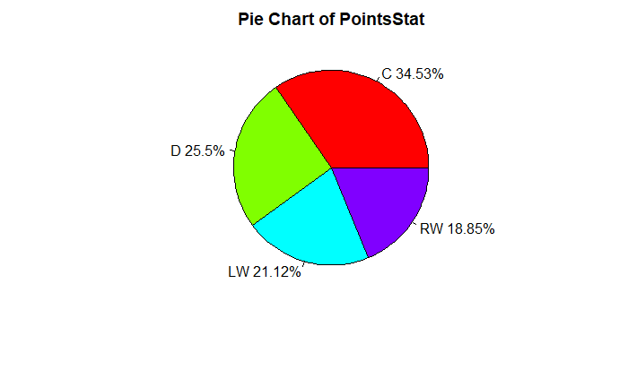

```r
library(ggplot2)
per <- round(PointsStat$Pospts / sum(PointsStat$Pospts)*100, 2)
lbls <- paste(PointsStat$OnePosition,per)
lbls <- paste(lbls,"%", sep = "")
pie(PointsStat$Pospts,labels = lbls, col=rainbow(length(lbls)),
   main="Pie Chart of PointsStat")
```

```r
NA
NA
```

###VIZUALIZACIJA PODATAKA

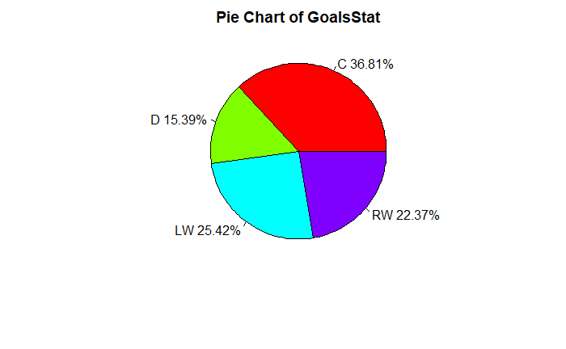

```r
per <- round(GoalsStat$Pospts / sum(GoalsStat$Pospts)*100, 2)
lbls <- paste(GoalsStat$OnePosition,per)
lbls <- paste(lbls,"%", sep = "")
pie(GoalsStat$Pospts,labels = lbls, col=rainbow(length(lbls)),
   main="Pie Chart of GoalsStat")
```

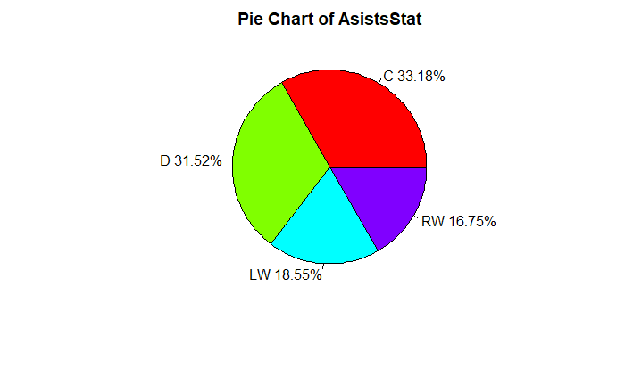

```r
per <- round(AsistsStat$Pospts / sum(AsistsStat$Pospts)*100, 2)
lbls <- paste(AsistsStat$OnePosition,per)
lbls <- paste(lbls,"%", sep = "")
pie(AsistsStat$Pospts,labels = lbls, col=rainbow(length(lbls)),
   main="Pie Chart of AsistsStat")
```

```r
NA
NA
```

###ZAKLJUČAK

Naša analiza zadatak nam otkriva da najviše bodova osvaja centarska pozicija s udjelom od 34,53% svih ostvarenih bodova.Da smo prije analize pokušali dati odgovor na pitanje koja pozicija donosi najviše bodova, vrlo vjerovatno bi naš odgovor bio centarska pozicija i temeljio bi se na tome da igrači na centarskoj poziciji igraju bliže protivničkom golu te zbog toga imaju veću šansu za postizanjem pogotka ili asistencije.Stoga ova analiza nema nekog prevelikog smisla jer smo i sami bez detaljne analize mogli vrlo vjerovatno točno pretpostaviti odgovor na naše pitanje.

Prethodno smo analizirali koje pozicije ostvaruje PTS, i nismo se iznenadili kad je analiza pokazala da centarska pozicija ostvaruje najviše PTS.No sada možemo i igru uvesti malo geografije i podijeliti igrače iz NHL na one iz Sj.Amerike i Europe te pokušati odgovoriti na pitanje: Zabijaju li Američki igrači više od Europskih?

###ZADATAK 7

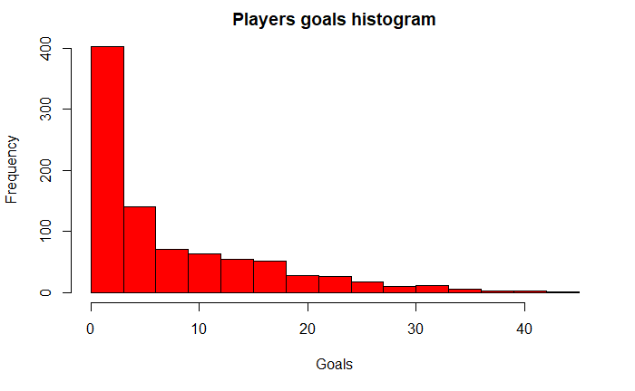

```r
histPlayersGoals <- hist(AllSits$G,
         breaks = seq(0, max(AllSits$G) + 3, 3),
         main="Players goals histogram",
         xlab="Goals",
         ylab = "Frequency",
         col="red"
         )
```

Plotanjem histograma ne možemo pokazati da uzorak broja golova dolazi iz normalne distribucije.

```r
americans = AllSits[AllSits$Nat == "USA" | AllSits$Nat == "CAN",]
europeans = AllSits[!(AllSits$Nat == "USA" | AllSits$Nat == "CAN"),]
```

Probat cemo prvo usporediti srednje vrijednosti:

```r
mean(americans$G)
```

```
[1] 7.16311
```

```r
mean(europeans$G)
```

```
[1] 8.642241
```

Pomalo iznenađujuće, ako gledamo srednje vrijednosti europljani zabijaju više golova od amerikanaca i kanađana. Provest ćemo test da pokažemo vrijedi li ta pretpstavka.

Iako iz histograma nismo mogli zaključiti da uzorak dolazi iz normalne distribucije, primjenom CGT možemo to zaključiti. Naime, promatramo stotine igrača što znači da je naš uzorak dovoljno velik, a i jasno je da su igrači međusobno nezavisni.

Provjerit ćemo jesu li varijance jednake:

```r
var(americans$G)
```

```
[1] 69.92297
```

```r
var(europeans$G)
```

```
[1] 84.67232
```

Razlika od 15ak je nezamjeriva. Provodimo var.test()

```r
var.test(americans$G, europeans$G)
```

```
    F test to compare two variances

data:  americans$G and europeans$G
F = 0.82581, num df = 655, denom df = 231, p-value = 0.07014
alternative hypothesis: true ratio of variances is not equal to 1
95 percent confidence interval:
 0.6640578 1.0157761
sample estimates:
ratio of variances
         0.8258067
```

p vrijednost iznosi 0.07014. Mi smo uzeli razinu značajnosti od 5%, te na temelju rezultata ovo testa ne odbacujemo pretpostavku da su varijance jednake.

Stvorili su se uvjeti da provedemo t.test() (Mogli bi provesti i z test s obzirom na veličinu populaciju, ali z.test() nije dio običnog r paketa)

```r
t.test(europeans$G, americans$G, alt="greater", var.equal = TRUE)
```

```
    Two Sample t-test

data:  europeans$G and americans$G
t = 2.2546, df = 886, p-value = 0.0122
alternative hypothesis: true difference in means is greater than 0
95 percent confidence interval:
 0.3988736       Inf
sample estimates:
mean of x mean of y
 8.642241  7.163110
```

###ZAKLJUČAK

p-vrijednost iznosi 0.0122. To znači da odbacujemo pretpostavku da amerikanci i europljani zabijaju jednako golova, u korist da europljani zabijaju više.

```r
americansT <- americans[americans$TOI.GP > 5,]
europeansT <- europeans[europeans$TOI.GP > 5,]
mean(americansT$G)
```

```
[1] 7.185015
```

```r
mean(europeansT$G)
```

```
[1] 8.679654
```

###DODATAK ZAKLJUČKU

Rezultati su bili malo iznenađujući, pa smo usporedili aritmetičku sredinu postignutih golova amerikanaca i europljana koji su igrali prosječno više od 5 minuta. Rezultati nagovještaju naš prijašnji zaključak.

###ZADATAK 8 ###UDIO OBRAMBENIH IGRAČA U AMERICI I EUROPI U ovom primjeru možemo se poslužiti testom o dvije proporcije.

```r
table(americans$Position)
```

```
      C     C/D    C/LW  C/LW/C C/LW/RW    C/RW C/RW/LW       D    D/RW      LW    LW/C LW/C/RW   LW/RW LW/RW/C      RW    RW/C RW/C/LW   RW/LW RW/LW/C
    113       1      44       1       6      33       5     224       2      58      33       5      24       4      58      20       3      18       4
```

```r
table(europeans$Position)
```

```
      C    C/LW C/LW/RW    C/RW C/RW/LW       D    D/LW      LW    LW/C LW/C/RW   LW/RW LW/RW/C      RW    RW/C RW/C/LW   RW/LW
     31      12       3       9       2      72       1      21      14       5      10       1      33       3       2      13
```

```r
NumOfAmericans <- nrow(americans)
NumOfEuropeans <- nrow(europeans)
americansDefenders <- nrow(americans[grepl("D",americans$Position), ])
europeansDefenders <- nrow(europeans[grepl("D",europeans$Position), ])

prop.test(x=c(americansDefenders, europeansDefenders), n = c(NumOfAmericans, NumOfEuropeans),
          alternative = "greater")
```

```
    2-sample test for equality of proportions with continuity correction

data:  c(americansDefenders, europeansDefenders) out of c(NumOfAmericans, NumOfEuropeans)
X-squared = 0.62073, df = 1, p-value = 0.2154
alternative hypothesis: greater
95 percent confidence interval:
 -0.03025692  1.00000000
sample estimates:
   prop 1    prop 2
0.3460366 0.3146552
```

###ZAKLJUČAK

S obzirom da je p-vrijednost jednaka 0.2154, nemožemo odbaciti H0 u korist H1 i tvrditi da je broj braniča u odnosu na ostale igrače veći u Sj.Americi nego u Europi.

###ZADATAK 9 #Provjera ovisnosti između minuta provedenih na terenu po utakmici i ozlijeđivanja Provesti ćemo test nezavinosti. Podatke ćemo prikazati kao kategorijske na način da minute provedene na terenu podijelimo u dvije kategorije jednake veličine (odnosno manje ili veće od medijana). Ozlijede dijelimo na one koje nisu imali ozlijedu te koji su imali jednu ili više ozlijeda.

H0: ozlijeđivanje i minute provedene na terenu su nezavisne H1: ozlijeđivanje i minute provedene na terenu nisu nezavisne

Koristimo kopiju naše prvotne tablice.

```r
AllSits_copy$Injuries[nchar(AllSits$Injuries) > 0] = "injury"
AllSits_copy$Injuries[nchar(AllSits$Injuries) == 0] = "no_injury"
```

```r
AllSits$Injuries
```

[output not shown]

[output cut: 281 more lines]

```r
AllSits_copy$Injuries
```

[output not shown]

[output cut: 59 more lines]

```r
AllSits_copy$TOI.GP[AllSits$TOI.GP >= median(AllSits$TOI.GP)] = "big minutes"
AllSits_copy$TOI.GP[AllSits$TOI.GP < median(AllSits$TOI.GP)] = "small minutes"
```

Igračima koji su u gornjoj polovici kod minutaže postavili smo minute u big minutes, ostalima u small minutes

```r
table_inj_min = table(AllSits_copy$Injuries, AllSits_copy$TOI.GP)
table_inj_min <- addmargins(table_inj_min)
table_inj_min
```

```
            big minutes small minutes Sum
  injury            268           209 477
  no_injury         177           234 411
  Sum               445           443 888
```

Moramo provjeriti još jednu stvar prije provedbe samog chisq.test() testa: je li frekvencija svakog razreda veća ili jednaka 5.

```r
for (col_names in colnames(table_inj_min)){
  for (row_names in rownames(table_inj_min)){
    if (!(row_names == 'Sum' | col_names == 'Sum') ){
      cat('Očekivane frekvencije za razred ',col_names,'-',row_names,': ',(table_inj_min[row_names,'Sum'] * table_inj_min['Sum',col_names]) / table_inj_min['Sum','Sum'],'\n')
    }
  }
}
```

```
Ocekivane frekvencije za razred  big minutes - injury :  239.0372
Ocekivane frekvencije za razred  big minutes - no_injury :  205.9628
Ocekivane frekvencije za razred  small minutes - injury :  237.9628
Ocekivane frekvencije za razred  small minutes - no_injury :  205.0372
```

Kao što vidimo, uvjet je zadovoljen. Ostalo je provesti sami test.

```r
chisq.test(tbl)
```

[output not shown]

###ZAKLJUČAK

S obzirom na jako malu p vrijednost odbacujemo H0 u korist H1, odnosno pokazali smo da minute igranja i ozlijeđivanje nisu nezavisne varijable

U školi/fakultetu često pišemo ispite iz kojih dobivamo različite ocjene.Na našu ocjenu utječe dosta faktora, od težine zadataka, gradiva koje pišemo, vremena utrošenog na savladavanje tog gradiva i slično.Istu stvar možmo primjeniti i na plaće igrača u našem podatkovom skupu.Dosta faktora može utjecati na plaću igrača, stoga će naš sljedeći zadataka biti:Ispitati vezu između plaće igrača s jedne strane i određenih varijabla s druge strane.U našem konkretnom slučaju uzet ćemo tri varijable koje bi mogle utjecati na plaću, a to su:PTS,minute i izbori u prvu,drugu ili treću najbolju šestorku lige.

###ZADATAK 10 ###PLAĆE I PTS, PLAĆE I IZBOR U STARS TE PLAĆE I MINUTE IGRANJA Ovdje ćemo koristiti model linearne regresije

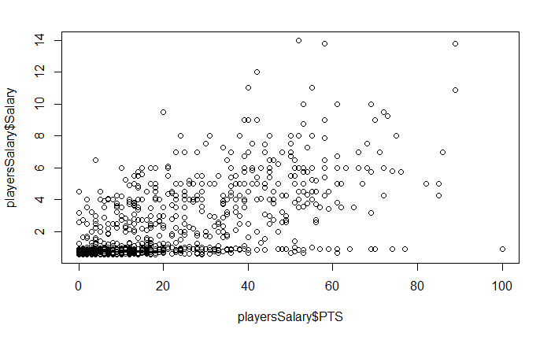

```r
require(stringr)
playersSalary$PTS <- AllSits[ ,c("PTS")]
playersSalary$TOI.GP <- AllSits[ ,c("TOI.GP")]
playersSalary$X1st <- AllSits[ ,c("X1st")]
playersSalary$X2nd <- AllSits[ ,c("X2nd")]
playersSalary$X3rd <- AllSits[ ,c("X3rd")]
playersSalary$PIM <- AllSits[ ,c("PIM")]
playersSalary$SCA <- AllSits[ ,c("SCA")]

playersSalary <- playersSalary[!is.na(playersSalary$Salary),]


#umjesto NA stavljamo 0 jer da je dobar igrac ne bi bio NA
playersSalary$X1st <- ifelse(is.na(playersSalary$X1st), 0, playersSalary$X1st)
playersSalary$X2nd <- ifelse(is.na(playersSalary$X2nd), 0, playersSalary$X2nd)
playersSalary$X3rd <- ifelse(is.na(playersSalary$X3rd), 0, playersSalary$X3rd)

playersSalary$Chosen <- playersSalary$X1st * 3 + playersSalary$X2nd * 2 + playersSalary$X3rd


plot(playersSalary$PTS, playersSalary$Salary)
```

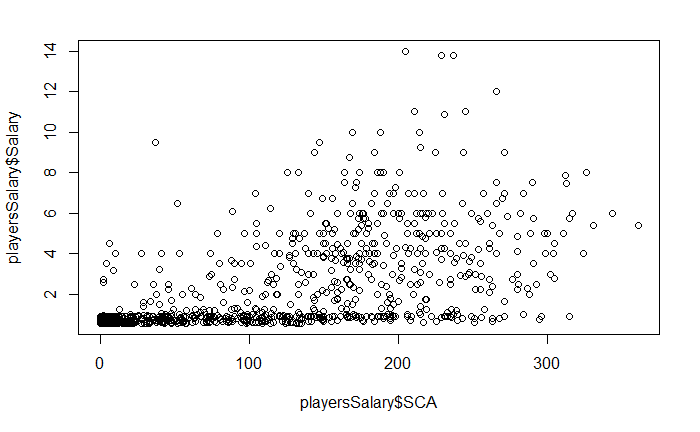

```r
plot(playersSalary$SCA, playersSalary$Salary)
```

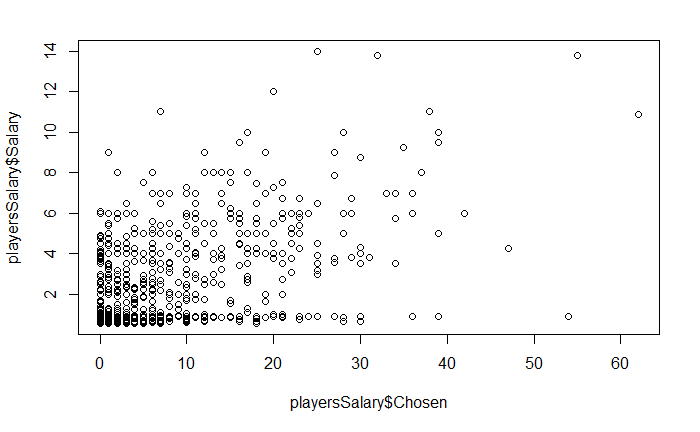

```r
plot(playersSalary$Chosen, playersSalary$Salary)
```

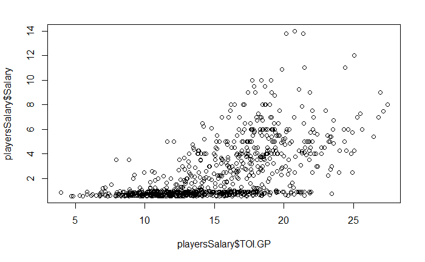

```r
plot(playersSalary$TOI.GP, playersSalary$Salary)
```

```r
NA
NA
```

Na osnovu scatter plotova možemo pretpostaviti da varijable koje promatramo pozitivno utječu na izlaznu varijablu(plaću igrača). Kako bismo ispitali utjecaje varijabli na izlaznu varijablu, procijenjujemo model jednostavne regresije za svaku nezavisnu varijablu. Zavisna varijabla regresijskih modela bit će plaća(salary).

### Linearna regresija

```
integer(0)
```

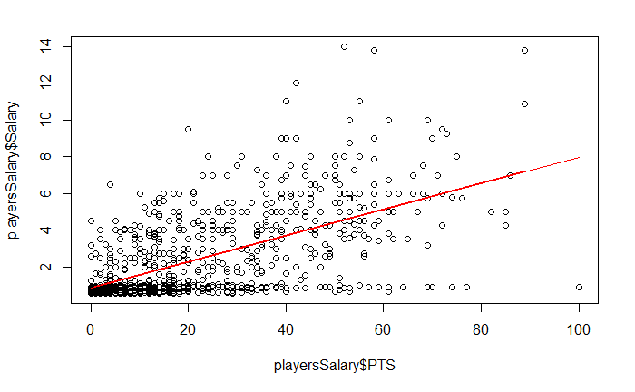

```r
#linearni model plaće igrača (Salary) i poena (golovi + asistencije = PTS)
fit.PTS = lm(playersSalary$Salary~playersSalary$PTS,data=playersSalary)

plot(playersSalary$PTS,playersSalary$Salary)+ #graficki prikaz podataka
lines(playersSalary$PTS,fit.PTS$fitted.values,col='red') #graficki prikaz procijenjenih vrijednosti iz modela
```

```
integer(0)
```

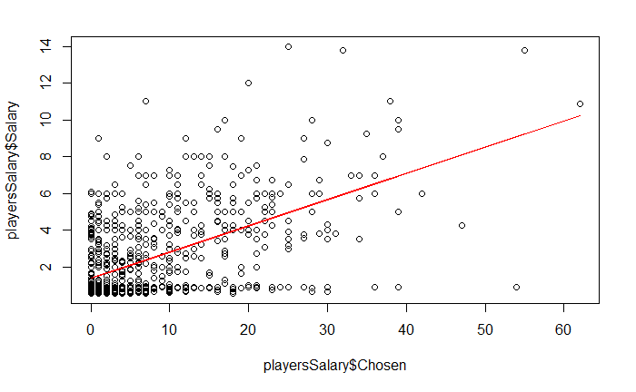

```r
#linearni model plaće igrača (Salary) i odabira u tri najbolja igrača
fit.chosen = lm(playersSalary$Salary~playersSalary$Chosen,data=playersSalary)

plot(playersSalary$Chosen,playersSalary$Salary)+ #graficki prikaz podataka
lines(playersSalary$Chosen,fit.chosen$fitted.values,col='red') #graficki prikaz procijenjenih vrijednosti iz modela
```

```
integer(0)
```

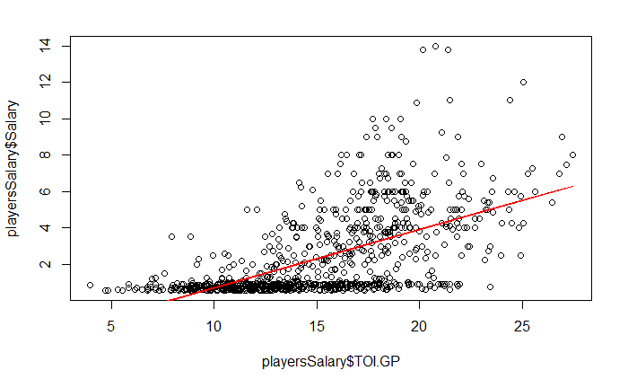

```r
#linearni model plaće igrača (Salary) i minuta po utakmici
fit.minutes = lm(playersSalary$Salary~playersSalary$TOI.GP,data=playersSalary)

plot(playersSalary$TOI.GP,playersSalary$Salary)+ #graficki prikaz podataka
lines(playersSalary$TOI.GP,fit.minutes$fitted.values,col='red') #graficki prikaz procijenjenih vrijednosti iz modela
```

```r
#linearni model plaće igrača (Salary) i šansi za gol kreiranih dok je igrač bio u igri
fit.SCA = lm(playersSalary$Salary~playersSalary$SCA,data=playersSalary)

length(playersSalary$SCA)
```

```
[1] 874
```

```r
length(fit.SCA$fitted.values)
```

```
[1] 873
```

```
integer(0)
```

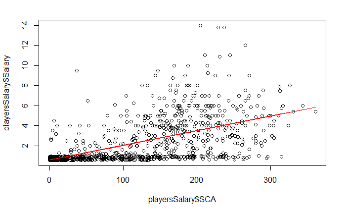

```r
plot(playersSalary$SCA,playersSalary$Salary)+ #graficki prikaz podataka
lines(playersSalary$SCA[!is.na(playersSalary$SCA)],fit.SCA$fitted.values,col='red') #graficki prikaz procijenjenih vrijednosti iz modela
```

Iz nagiba pravaca linearne regresije možemo vidjeti da su naše pretpostavke o efektima promatranih varijabli bile opravdane. Kako bi dalje analizirali dobivene modele, moramo provjeriti da naše pretpostavke normalnosti reziduala i homogenosti varijance nisu pogrešne.

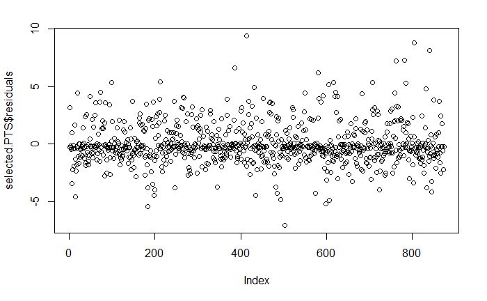

```r
####  Bodovi
selected.PTS = fit.PTS

plot(selected.PTS$residuals) #gledajuci reziduale na ovaj nacin tesko je suditi o normalnosti
```

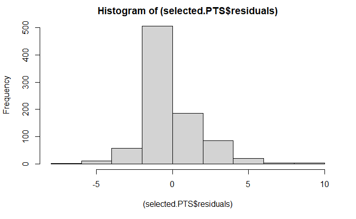

```r
#histogram je vrlo interpretativan
hist((selected.PTS$residuals))
```

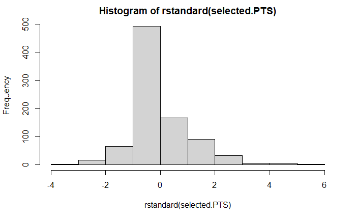

```r
hist(rstandard(selected.PTS))
```

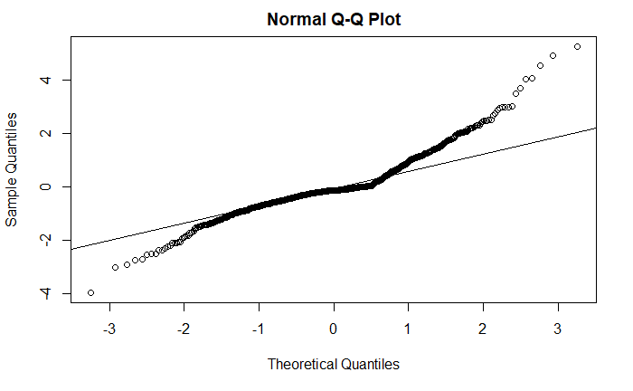

```r
#q-q plot reziduala s linijom normalne distribucije
qqnorm(rstandard(selected.PTS))
qqline(rstandard(selected.PTS))
```

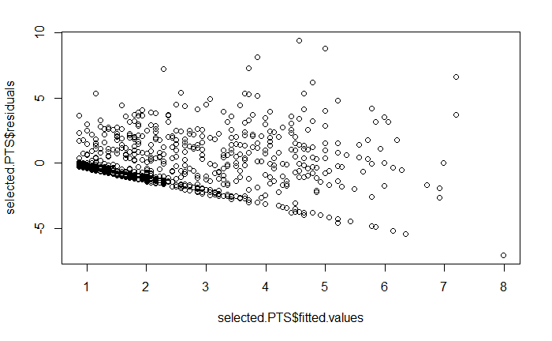

```r
plot(selected.PTS$fitted.values,selected.PTS$residuals) #reziduale je dobro prikazati u ovisnosti o procjenama modela
```

```r
#KS test na normalnost
ks.test(rstandard(fit.PTS),'pnorm')
```

```
ties should not be present for the Kolmogorov-Smirnov test
```

```
    One-sample Kolmogorov-Smirnov test

data:  rstandard(fit.PTS)
D = 0.18129, p-value < 2.2e-16
alternative hypothesis: two-sided
```

```r
require(nortest)
lillie.test(rstandard(fit.PTS))
```

```
    Lilliefors (Kolmogorov-Smirnov) normality test

data:  rstandard(fit.PTS)
D = 0.18129, p-value < 2.2e-16
```

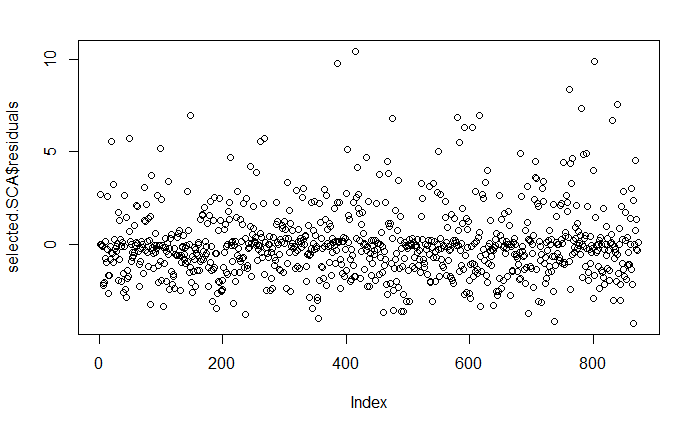

```r
####  Bodovi
selected.SCA = fit.SCA

plot(selected.SCA$residuals)
```

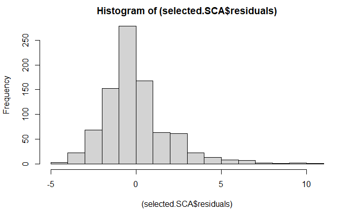

```r
#histogram je vrlo interpretativan
hist((selected.SCA$residuals))
```

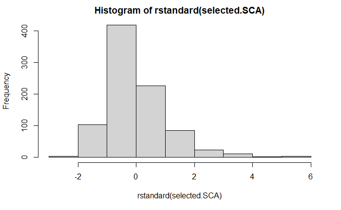

```r
hist(rstandard(selected.SCA))
```

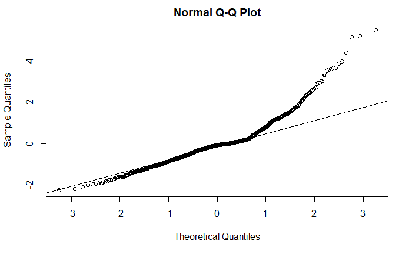

```r
#q-q plot reziduala s linijom normalne distribucije
qqnorm(rstandard(selected.SCA))
qqline(rstandard(selected.SCA))
```

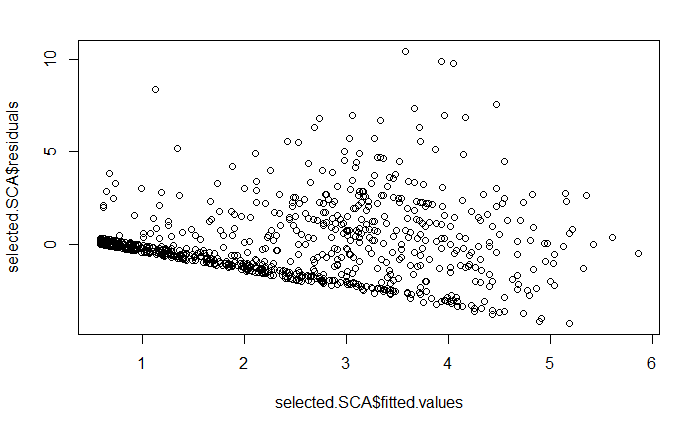

```r
plot(selected.SCA$fitted.values,selected.SCA$residuals) #reziduale je dobro prikazati u ovisnosti o procjenama modela
```

```r
#KS test na normalnost
ks.test(rstandard(fit.SCA),'pnorm')
```

```
ties should not be present for the Kolmogorov-Smirnov test
```

```
    One-sample Kolmogorov-Smirnov test

data:  rstandard(fit.SCA)
D = 0.15584, p-value < 2.2e-16
alternative hypothesis: two-sided
```

```r
require(nortest)
lillie.test(rstandard(fit.SCA))
```

```
    Lilliefors (Kolmogorov-Smirnov) normality test

data:  rstandard(fit.SCA)
D = 0.15588, p-value < 2.2e-16
```

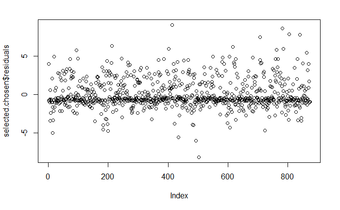

```r
####  Izabranost u stars
selected.chosen = fit.chosen

plot(selected.chosen$residuals) #gledajuci reziduale na ovaj nacin tesko je suditi o normalnosti
```

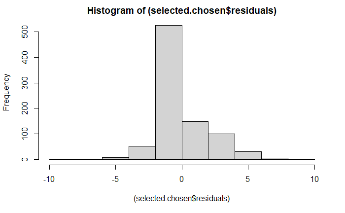

```r
#histogram je vrlo interpretativan
hist((selected.chosen$residuals))
```

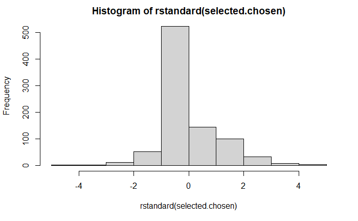

```r
hist(rstandard(selected.chosen))
```

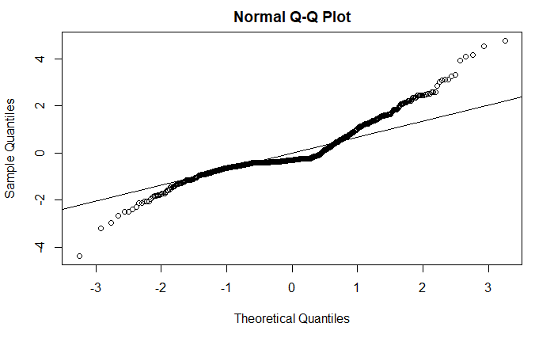

```r
#q-q plot reziduala s linijom normalne distribucije
qqnorm(rstandard(selected.chosen))
qqline(rstandard(selected.chosen))
```

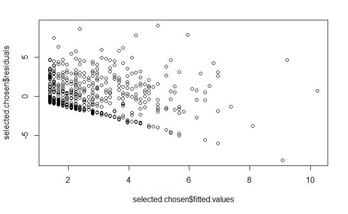

```r
plot(selected.chosen$fitted.values,selected.chosen$residuals) #reziduale je dobro prikazati u ovisnosti o procjenama modela
```

```r
#KS test na normalnost
ks.test(rstandard(fit.chosen),'pnorm')
```

```
ties should not be present for the Kolmogorov-Smirnov test
```

```
    One-sample Kolmogorov-Smirnov test

data:  rstandard(fit.chosen)
D = 0.20184, p-value < 2.2e-16
alternative hypothesis: two-sided
```

```r
lillie.test(rstandard(fit.chosen))
```

```
    Lilliefors (Kolmogorov-Smirnov) normality test

data:  rstandard(fit.chosen)
D = 0.20168, p-value < 2.2e-16
```

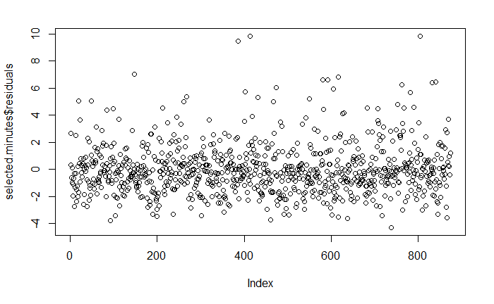

```r
####  Vrijeme igranja po utakmici
selected.minutes = fit.minutes

plot(selected.minutes$residuals) #gledajuci reziduale na ovaj nacin tesko je suditi o normalnosti
```

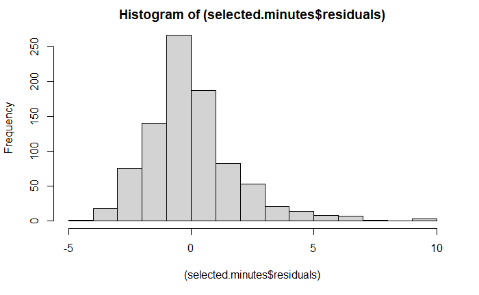

```r
#histogram je vrlo interpretativan
hist((selected.minutes$residuals))
```

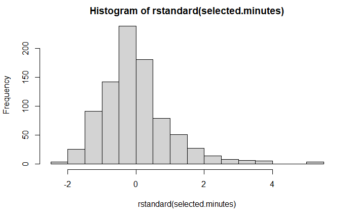

```r
hist(rstandard(selected.minutes))
```

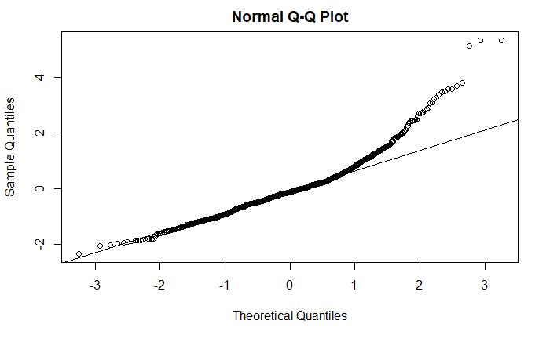

```r
#q-q plot reziduala s linijom normalne distribucije
qqnorm(rstandard(selected.minutes))
qqline(rstandard(selected.minutes))
```

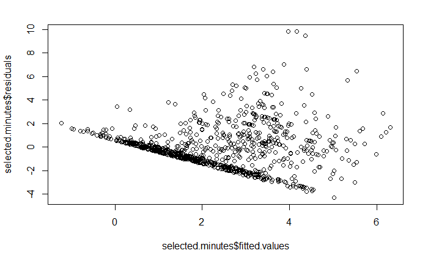

```r
plot(selected.minutes$fitted.values,selected.minutes$residuals) #reziduale je dobro prikazati u ovisnosti o procjenama modela
```

```r
#KS test na normalnost
ks.test(rstandard(fit.minutes),'pnorm')
```

```
ties should not be present for the Kolmogorov-Smirnov test
```

```
    One-sample Kolmogorov-Smirnov test

data:  rstandard(fit.minutes)
D = 0.10693, p-value = 4.18e-09
alternative hypothesis: two-sided
```

```r
require(nortest)
lillie.test(rstandard(fit.minutes))
```

```
    Lilliefors (Kolmogorov-Smirnov) normality test

data:  rstandard(fit.minutes)
D = 0.10704, p-value < 2.2e-16
```

```r
cor(playersSalary$PTS,playersSalary$Salary)
```

```
[1] 0.622702
```

```r
cor.test(playersSalary$PTS,playersSalary$Salary)
```

```
    Pearson's product-moment correlation

data:  playersSalary$PTS and playersSalary$Salary
t = 23.5, df = 872, p-value < 2.2e-16
alternative hypothesis: true correlation is not equal to 0
95 percent confidence interval:
 0.5803534 0.6616918
sample estimates:
     cor
0.622702
```

```r
summary(fit.PTS)
```

```
Call:
lm(formula = playersSalary$Salary ~ playersSalary$PTS, data = playersSalary)

Residuals:
    Min      1Q  Median      3Q     Max
-7.0621 -0.9229 -0.2654  0.6465  9.4313

Coefficients:
                  Estimate Std. Error t value Pr(>|t|)
(Intercept)        0.86544    0.08697   9.951   <2e-16 ***
playersSalary$PTS  0.07122    0.00303  23.500   <2e-16 ***
---
Signif. codes:  0 ‘***’ 0.001 ‘**’ 0.01 ‘*’ 0.05 ‘.’ 0.1 ‘ ’ 1

Residual standard error: 1.799 on 872 degrees of freedom
Multiple R-squared:  0.3878,    Adjusted R-squared:  0.3871
F-statistic: 552.3 on 1 and 872 DF,  p-value: < 2.2e-16
```

```r
cor(playersSalary$SCA,playersSalary$Salary)
```

```
[1] NA
```

```r
cor.test(playersSalary$SCA,playersSalary$Salary)
```

```
    Pearson's product-moment correlation

data:  playersSalary$SCA and playersSalary$Salary
t = 19.913, df = 871, p-value < 2.2e-16
alternative hypothesis: true correlation is not equal to 0
95 percent confidence interval:
 0.5119692 0.6032831
sample estimates:
      cor
0.5593206
```

```r
summary(fit.SCA)
```

```
Call:
lm(formula = playersSalary$Salary ~ playersSalary$SCA, data = playersSalary)

Residuals:
    Min      1Q  Median      3Q     Max
-4.2587 -1.1300 -0.1482  0.5020 10.4213

Coefficients:
                   Estimate Std. Error t value Pr(>|t|)
(Intercept)       0.5876621  0.1086068   5.411 8.11e-08 ***
playersSalary$SCA 0.0145907  0.0007327  19.913  < 2e-16 ***
---
Signif. codes:  0 ‘***’ 0.001 ‘**’ 0.01 ‘*’ 0.05 ‘.’ 0.1 ‘ ’ 1

Residual standard error: 1.907 on 871 degrees of freedom
  (1 observation deleted due to missingness)
Multiple R-squared:  0.3128,    Adjusted R-squared:  0.3121
F-statistic: 396.5 on 1 and 871 DF,  p-value: < 2.2e-16
```

```r
cor(playersSalary$Chosen,playersSalary$Salary)
```

```
[1] 0.5633451
```

```r
cor.test(playersSalary$Chosen,playersSalary$Salary)
```

```
    Pearson's product-moment correlation

data:  playersSalary$Chosen and playersSalary$Salary
t = 20.134, df = 872, p-value < 2.2e-16
alternative hypothesis: true correlation is not equal to 0
95 percent confidence interval:
 0.5163201 0.6069833
sample estimates:
      cor
0.5633451
```

```r
summary(fit.chosen)
```

```
Call:
lm(formula = playersSalary$Salary ~ playersSalary$Chosen, data = playersSalary)

Residuals:
    Min      1Q  Median      3Q     Max
-8.1630 -0.8890 -0.5861  0.8460  9.0482

Coefficients:
                     Estimate Std. Error t value Pr(>|t|)
(Intercept)          1.386142   0.079410   17.46   <2e-16 ***
playersSalary$Chosen 0.142626   0.007084   20.13   <2e-16 ***
---
Signif. codes:  0 ‘***’ 0.001 ‘**’ 0.01 ‘*’ 0.05 ‘.’ 0.1 ‘ ’ 1

Residual standard error: 1.9 on 872 degrees of freedom
Multiple R-squared:  0.3174,    Adjusted R-squared:  0.3166
F-statistic: 405.4 on 1 and 872 DF,  p-value: < 2.2e-16
```

```r
cor(playersSalary$TOI.GP,playersSalary$Salary)
```

```
[1] 0.5952072
```

```r
cor.test(playersSalary$TOI.GP,playersSalary$Salary)
```

```
    Pearson's product-moment correlation

data:  playersSalary$TOI.GP and playersSalary$Salary
t = 21.873, df = 872, p-value < 2.2e-16
alternative hypothesis: true correlation is not equal to 0
95 percent confidence interval:
 0.5506272 0.6364017
sample estimates:
      cor
0.5952072
```

```r
summary(fit.minutes)
```

```
Call:
lm(formula = playersSalary$Salary ~ playersSalary$TOI.GP, data = playersSalary)

Residuals:
    Min      1Q  Median      3Q     Max
-4.2725 -1.0685 -0.2238  0.7512  9.8383

Coefficients:
                     Estimate Std. Error t value Pr(>|t|)
(Intercept)          -2.50087    0.22933  -10.90   <2e-16 ***
playersSalary$TOI.GP  0.32078    0.01467   21.87   <2e-16 ***
---
Signif. codes:  0 ‘***’ 0.001 ‘**’ 0.01 ‘*’ 0.05 ‘.’ 0.1 ‘ ’ 1

Residual standard error: 1.848 on 872 degrees of freedom
Multiple R-squared:  0.3543,    Adjusted R-squared:  0.3535
F-statistic: 478.4 on 1 and 872 DF,  p-value: < 2.2e-16
```

###ZAKLJUČAK

Došli smo do zaključka da varijable koje smo odabrali pozitivno utječu na visinu plaće, ali i da postoji određeni stupanj korelacije među njima, što bi nam dosta otežalo izvedbu višestruke regresije iz ovih varijabli.

U gotovo svakom sportu biraju se najbolji od njaboljih.Za NHL vrijedi da svake godine se biraju 3 najbolje postave.Stoga ćemo probati uzeti u obzir neke varijable koje bi mogle ovisiti o izboru u najbolju postavu.

###ZADATAK 11 Opet koristimo model linearne regresije

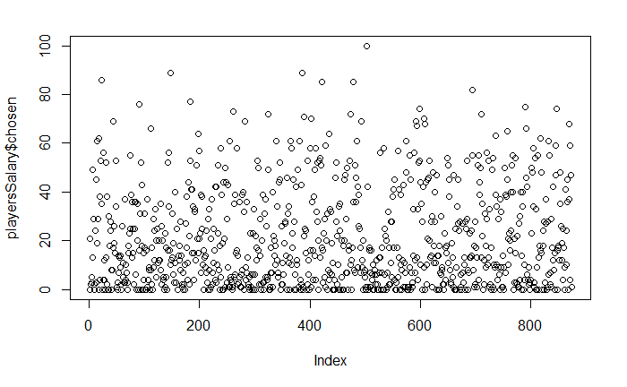

```r
overall <- AllSits_copy[, c("First.Name", "Last.Name", "Ovrl")]
overall <- overall[!is.na(overall$Ovrl), ]

overall <-  merge(overall, playersSalary, by = c("Last.Name", "First.Name"), all.x=TRUE)

overall <- overall[, (names(overall) %in% c("Last.Name", "First.Name", "Chosen", "Ovrl"))]
overall <- overall[!is.na(overall$Chosen), ]


plot(playersSalary$PTS, playersSalary$chosen)
```

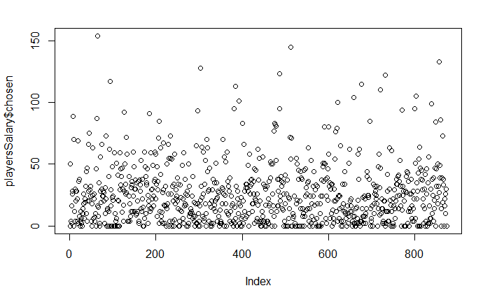

```r
plot(playersSalary$PIM, playersSalary$chosen)
```

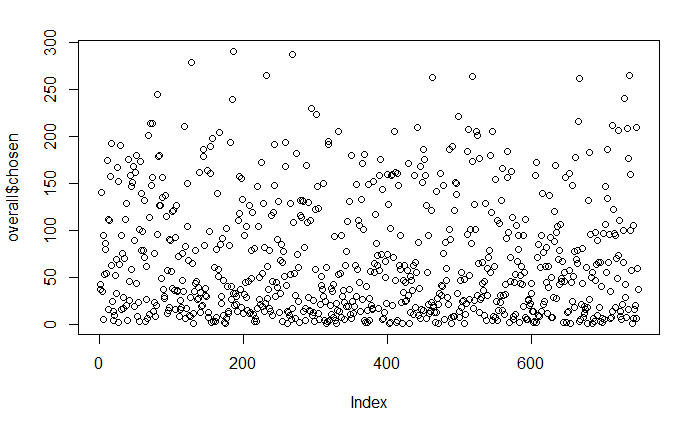

```r
plot(overall$Ovrl, overall$chosen)
```

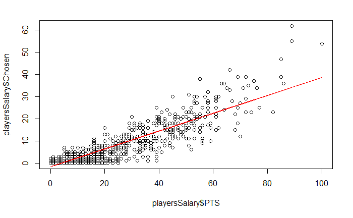

```r
fit.pts = lm(playersSalary$Chosen~playersSalary$PTS, data=playersSalary)
fit.pim = lm(playersSalary$Chosen~playersSalary$PIM, data=playersSalary)
fit.ovrl = lm(overall$Chosen~overall$Ovrl, data=overall)


plot(playersSalary$PTS,  playersSalary$Chosen)
lines(playersSalary$PTS, fit.pts$fitted.values, col='red')
```

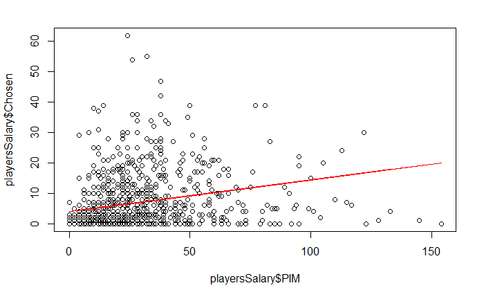

```r
plot(playersSalary$PIM, playersSalary$Chosen)
lines(playersSalary$PIM, fit.pim$fitted.values, col='red')
```

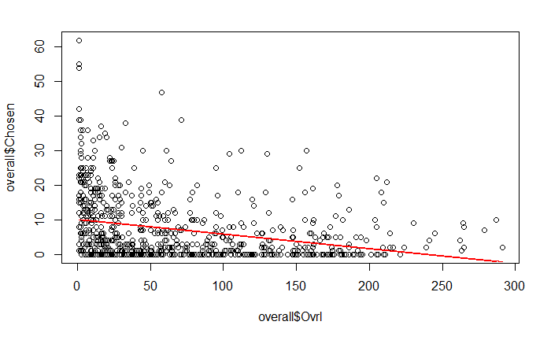

```r
plot(overall$Ovrl, overall$Chosen)
lines(overall$Ovrl, fit.ovrl$fitted.values, col='red')
```

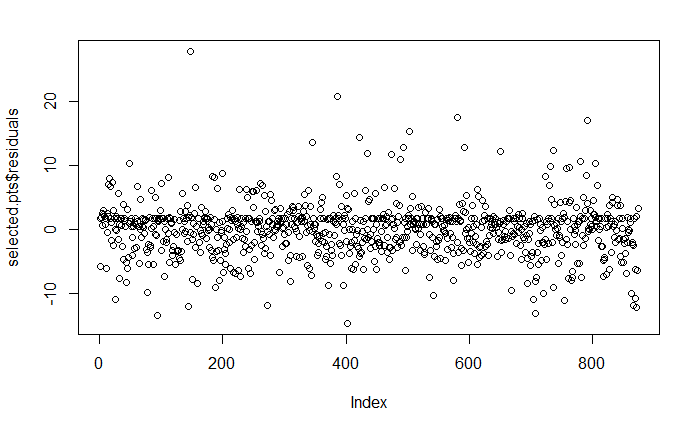

```r
####  Bodovi
selected.pts = fit.pts

plot(selected.pts$residuals)
```

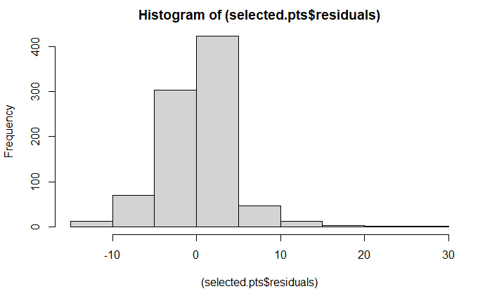

```r
#histogram je vrlo interpretativan
hist((selected.pts$residuals))
```

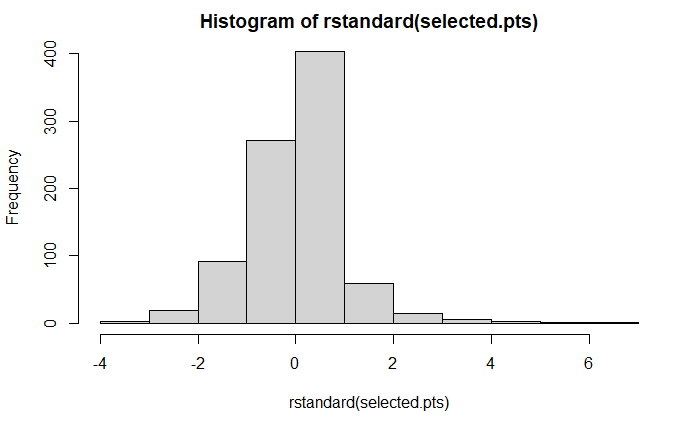

```r
hist(rstandard(selected.pts))
```

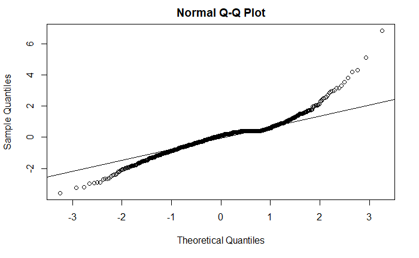

```r
#q-q plot reziduala s linijom normalne distribucije
qqnorm(rstandard(selected.pts))
qqline(rstandard(selected.pts))
```

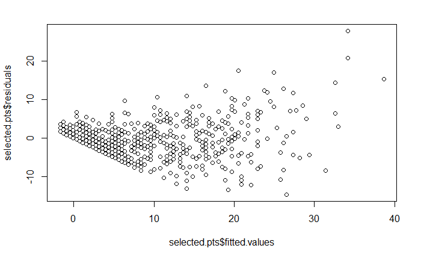

```r
plot(selected.pts$fitted.values,selected.pts$residuals)
```

```r
#KS test na normalnost
ks.test(rstandard(fit.pts),'pnorm')
```

```
ties should not be present for the Kolmogorov-Smirnov test
```

```
    One-sample Kolmogorov-Smirnov test

data:  rstandard(fit.pts)
D = 0.13102, p-value = 1.856e-13
alternative hypothesis: two-sided
```

```r
require(nortest)
lillie.test(rstandard(fit.pts))
```

```
    Lilliefors (Kolmogorov-Smirnov) normality test

data:  rstandard(fit.pts)
D = 0.13139, p-value < 2.2e-16
```

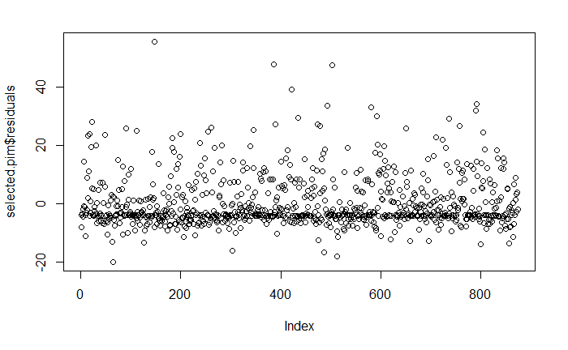

```r
####  PIM
selected.pim = fit.pim

plot(selected.pim$residuals)
```

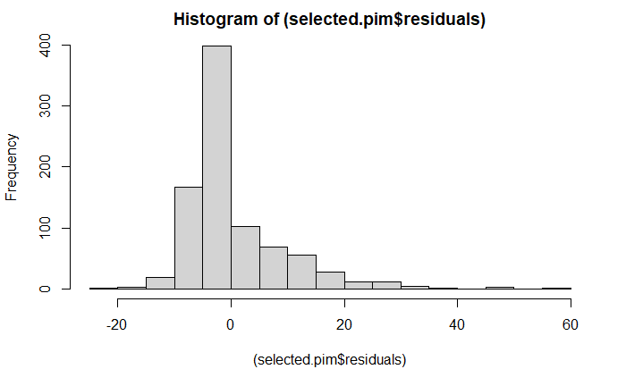

```r
#histogram je vrlo interpretativan
hist((selected.pim$residuals))
```

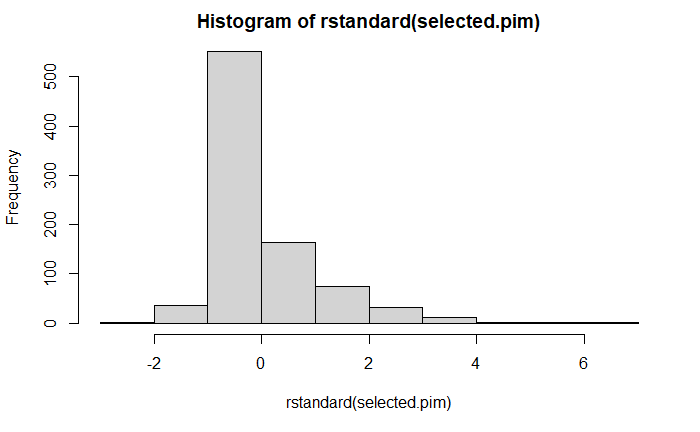

```r
hist(rstandard(selected.pim))
```

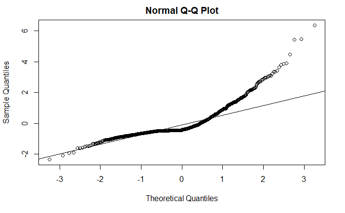

```r
#q-q plot reziduala s linijom normalne distribucije
qqnorm(rstandard(selected.pim))
qqline(rstandard(selected.pim))
```